# TCP-seq quick analysis

Edward Wallace

07/01/2022

# Summary

Analysis of TCP-seq data from Archer et al 2016 (PMID: 27437580), to compare ribosomal small subunit (40S) occupancy with Ssd1 on target genes SUN4 and UTH1.

## Load data

Loads the supplementary data `FP_metagene` from Archer 2016:

> Archer, Stuart (2016): Coordinates of TCP-seq reads, mapped to yeast mRNAs.. figshare. Dataset. https://doi.org/10.6084/m9.figshare.3206698.v2

We immediately filter for only a single sample, `WT cells: SSU`.

**Note: you will need to change the file location to run locally on a different computer. The file is 24MB compressed. In would be better to use the library `rfigshare`**.

```r
FP_WTSSU <- read_tsv("~/Downloads/FP_metagene.txt") %>%
  filter(sample == "WT cells: SSU") %>%
  rename(Gene = gene)
```

## Plot pileup of reads on a single gene, PAB1 / YER165W

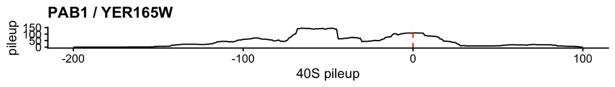

```r
count_fp_pos <- function(pos, data) {
  sum( ( data$start <= pos ) & ( data$min_end >= pos ) )
}

calculate_pileup_pos <- function(df, pos = -1000:5000) {
  tibble(pos = pos,
         pileup = sapply(pos,count_fp_pos, data = df))
}

pileup_PAB1 <-
  FP_WTSSU %>%
  filter(Gene == "YER165W") %>%
  calculate_pileup_pos

ggplot(data = pileup_PAB1, aes(x=pos, y=pileup)) +
  geom_line() +
  xlim(-200,100) +
  geom_vline(xintercept = 0, linetype = "dashed", colour = "red") +
  labs(title = "PAB1 / YER165W", x = "40S pileup")
```

## Calculate ratio of counts on 5’UTR to 5’UTR + start codon, and plot

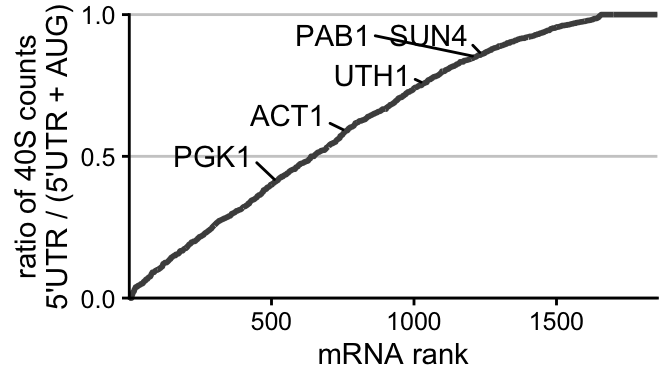

```r
countratio_bygene_over20 <-
  FP_WTSSU %>%
  group_by(Gene) %>%
  summarise(count_AUG = sum(start >= -16 & start <= -10),
            count_5UTR = sum(start < -16),
            count_total = n()) %>%
  mutate(ratio_five_fiveAUG = count_5UTR / (count_5UTR + count_AUG)) %>%
  filter(count_5UTR + count_AUG >= 20) %>%
  arrange(ratio_five_fiveAUG) %>%
  ungroup() %>%
  mutate(rank = 1:nrow(.))

favourite_gene_df <-
  tribble(~gname, ~Gene,
          "PAB1", "YER165W",
          "SUN4", "YNL066W",
          "ACT1", "YFL039C",
          "UTH1", "YKR042W",
          "PGK1", "YCR012W")

ggplot(data = countratio_bygene_over20, aes(x = rank, y = ratio_five_fiveAUG)) +
  geom_line(colour = "grey30", size = 1) +
  geom_text_repel(data = left_join(favourite_gene_df,
                                   countratio_bygene_over20),
                  aes(label = gname),
                  nudge_x = -200, nudge_y = 0.1, min.segment.length = 0) +
  labs(x = "mRNA rank", y = "ratio of 40S counts\n5'UTR / (5'UTR + AUG)") +
  coord_cartesian(expand = FALSE, clip = "off") +
  scale_y_continuous(breaks = c(0,0.5, 1)) +
  theme(panel.grid.major.y = element_line(colour= "grey80"))
```

## Calculate ratio of highest peak on 5’UTR to 5’UTR + start codon, and plot

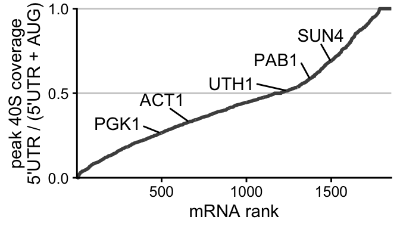

```r
pileups_WTSSU_over20 <-
  FP_WTSSU %>%
  filter(Gene %in% countratio_bygene_over20$Gene) %>%
  group_by(Gene) %>%
  do(calculate_pileup_pos(.))

peakratio_bygene_over20 <-
  pileups_WTSSU_over20 %>%
  summarise(maxpeak_AUG = max( (pos >= -16 & pos <= -10) * pileup ),
            maxpeak_5UTR = max( (pos < -16) * pileup )) %>%
  mutate(ratio_five_fiveAUG = maxpeak_5UTR / (maxpeak_5UTR + maxpeak_AUG)) %>%
  arrange(ratio_five_fiveAUG) %>%
  ungroup() %>%
  mutate(rank = 1:nrow(.))

favourite_gene_df <-
  tribble(~gname, ~Gene,
          "PAB1", "YER165W",
          "SUN4", "YNL066W",
          "ACT1", "YFL039C",
          "UTH1", "YKR042W",
          "PGK1", "YCR012W")

ggplot(data = peakratio_bygene_over20, aes(x = rank, y = ratio_five_fiveAUG)) +
  geom_line(colour = "grey30", size = 1) +
  geom_text_repel(data = left_join(favourite_gene_df,
                                   peakratio_bygene_over20),
                  aes(label = gname),
                  nudge_x = -200, nudge_y = 0.1, min.segment.length = 0) +
  labs(x = "mRNA rank", y = "peak 40S coverage\n5'UTR / (5'UTR + AUG)") +
  coord_cartesian(expand = FALSE, clip = "off") +
  scale_y_continuous(breaks = c(0,0.5, 1)) +
  theme(panel.grid.major.y = element_line(colour= "grey80"))
```

```r
ggsave("figure/TCPseq_peak_ratio_draft.pdf", height = 2, width = 3.5)
```

## Define plot functions for bedgraph and pileup in genomic coordinates

This is adapted badly from the code in `bedgraph_genome_plots.Rmd`.

These functions plot in genomic coordinates. By contrast, the `FP_metagene` data from Archer et al is described in relative to th start codon on the positive strand.

```r
onebreak <- function(lims,digits=1) {
    # select axis breaks/ticks with 0 and one tick
    c(0, signif(max(lims*.8), digits=digits) )
}

plot_bg <- function(bgbig,chromr,startr,endr,strandrev=FALSE,title=NULL,colourmain="blue") {
    # plot bedgraph in genomic co-ordinates, normalized to max value
    bgsmall <- bgbig %>%
                   filter(chrom==chromr, start >= startr, end <= endr)
    value_max <- max(bgsmall$value)
    bgplot <-
        ggplot(data=bgsmall) +
        geom_rect(
               aes(ymin=0,ymax=value/value_max,xmin=start,xmax=end),
               colour=colourmain,fill=colourmain) +
        facet_grid(Type+Sample ~.,scales="free_y") +
        scale_y_continuous(expand=c(0,0),breaks=c(0,0.5,1)) +
        expand_limits(x=c(startr,endr)) +
        labs(title=title, x=chromr, y="Reads")
    if (strandrev) {
        return( bgplot + scale_x_reverse(expand=c(0,0),limits=c(endr,startr)) )
    } else {
        return( bgplot + scale_x_continuous(expand=c(0,0),limits=c(startr,endr)) )
    }
}

read_gff <- function(file){
    # tidyverse read gff function from rmonad vignette
    # https://cran.r-project.org/web/packages/rmonad/vignettes/gff-processing.html
    readr::read_tsv(
        file,
        col_names = c(
            "chrom",
            "source",
            "type",
            "start",
            "end",
            "score",
            "strand",
            "phase",
            "attr"
        ),
        na        = ".",
        comment   = "#",
        col_types = "ccciidcic"
    )
}

plot_mRNA <- function(gff,gene,pad=0,gff_extra=NULL,colour_extra="red") {
    # Plot an mRNA track (mRNA + five_prime_UTR + three_prime_UTR) from gff
    # for only one mRNA transcript, names "gene"
    gffsmall <- gff %>%
        filter(Gene==gene)
    mRNA_plot <-
      ggplot(data=gffsmall,
           aes(xmin=start,xmax=end)) +
        # geom_rect(data=filter(gffsmall,type=="mRNA"),
        #           aes(ymin=-1,ymax=1),fill="darkblue") +
        geom_rect(data=filter(gffsmall,type=="five_prime_UTR"),
                  aes(ymin=-4,ymax=4),fill="darkblue") +
        geom_rect(data=filter(gffsmall,type=="three_prime_UTR"),
                  aes(ymin=-4,ymax=4),fill="darkblue") +
        geom_rect(data=filter(gffsmall,type=="CDS"),
                  aes(ymin=-10,ymax=10),fill="darkblue") +
        theme_nothing()
        # theme(axis.text.x = element_text(colour="black"),
        #       axis.ticks.x=element_line(colour="black",size=0.5))
    if(!is.null(gff_extra)) {
        # select location of the mRNA features in gffsmall
        small_chrom <- gffsmall$chrom[1]
        small_strand <- gffsmall$strand[1]
        small_start <- min(gffsmall$start) - pad
        small_end   <- max(gffsmall$end) + pad
        # filter gff_extra for only completely overlapping features
        gff_extrasmall <- filter(gff_extra,
                                 chrom == small_chrom,
                                 strand == small_strand,
                                 start >= small_start,
                                 end <= small_end)
        mRNA_plot <-
          mRNA_plot +
          geom_rect(data=gff_extrasmall,
                    aes(ymin=-8,ymax=8),fill=colour_extra)
    }
    return(mRNA_plot)
}

# plot_mRNA(gff_H99,"CNAG_06125")

plot_mRNAbg <- function(bgbig,gff,gene,strandrev=FALSE,pad=100,ptitle=NULL,gff_extra=NULL,colour_extra="red") {
    gffmRNA <- gff %>%
        filter(Gene==gene)
    startr <- min(gffmRNA$start) - pad
    endr   <- max(gffmRNA$end) + pad
    bgplot <- plot_bg(bgbig,
                      chromr = gffmRNA$chrom[1],
                      startr = startr,
                      endr = endr,
                      strandrev = strandrev)
    mplot <- plot_mRNA(gff,gene,pad=pad,
                       gff_extra=gff_extra,colour_extra=colour_extra)
    if (strandrev) {
        mplot <- mplot +
            scale_x_reverse(expand=c(0,0),limits=c(endr,startr))
    } else {
        mplot <- mplot +
            scale_x_continuous(expand=c(0,0),limits=c(startr,endr))
    }
    if (is.null(ptitle)) {
      ptitle <- gene
    }
    tplot <- ggdraw() +
        draw_label(ptitle,fontface = 'bold',size = 11)
    plot_grid(tplot,mplot,bgplot,
              rel_heights = c(0.09,0.05,0.86),
              ncol=1,align="v",axis="lr")
}

plot_mRNAbg_pileup <- function(bgbig,gff,pileupSSU, gene,strandrev=FALSE,pad=100,ptitle=NULL,gff_extra=NULL,colour_extra="red") {
    gffmRNA <- gff %>%
        filter(Gene==gene)
    startr <- min(gffmRNA$start) - pad
    endr   <- max(gffmRNA$end) + pad
    bgplot <- plot_bg(bgbig,
                      chromr = gffmRNA$chrom[1],
                      startr = startr,
                      endr = endr,
                      strandrev = strandrev) +
      theme_nothing()
    pileup_gene <- filter(pileupSSU, Gene == gene)
    pileup_max <- max(pileup_gene$pileup)
    mplot <- plot_mRNA(gff,gene,pad=pad,
                       gff_extra=gff_extra,colour_extra=colour_extra)
    if (strandrev) {
        mplot <- mplot +
            scale_x_reverse(expand=c(0,0),limits=c(endr,startr))
        warning("pileup_gene is not yet tested if strandrev TRUE")
        startcodon <- max(filter(gffmRNA,type=="CDS")$end)
        bgplot <- bgplot +
          geom_line(data = pileup_gene,
                    aes(x = startcodon - pos, y = pileup/pileup_max),
                    colour = "red")
    } else {
        mplot <- mplot +
            scale_x_continuous(expand=c(0,0),limits=c(startr,endr))
        startcodon <- min(filter(gffmRNA,type=="CDS")$start)
        bgplot <- bgplot +
          geom_line(data = pileup_gene,
                    aes(x = startcodon + pos, y = pileup/pileup_max),
                    colour = "red")
    }
    if (is.null(ptitle)) {
      ptitle <- gene
    }
    tplot <- ggdraw() +
        draw_label(ptitle,fontface = 'bold',size = 11)
    plot_grid(tplot,bgplot,mplot,
              rel_heights = c(0.09,0.86,0.05),
              ncol=1,align="v",axis="lr")
}
```

## Load bedgraphs of Ssd1 CRAC reads

```r
bedgraph_dir <- "../Ssd1_CRAC_demult_dedup_20190114_all/bedgraph_genomecov/"
bgall <- bind_rows(
    read_bedgraph(paste0(bedgraph_dir,"20190114_Ssd1_CRAC_trimmed_NNNGTGAGC_SSD1_3_30_plus.bedgraph")) %>%
        mutate(Type="",Sample="A",strand="plus",strandm=1),
    read_bedgraph(paste0(bedgraph_dir,"20190114_Ssd1_CRAC_trimmed_NNNGTGAGC_SSD1_3_30_minus.bedgraph")) %>%
        mutate(Type="",Sample="A",strand="minus",strandm=-1),
    read_bedgraph(paste0(bedgraph_dir,"20190114_Ssd1_CRAC_trimmed_NNNTGGAGC_SSD1_4_30_plus.bedgraph")) %>%
        mutate(Type="",Sample="B",strand="plus",strandm=1),
    read_bedgraph(paste0(bedgraph_dir,"20190114_Ssd1_CRAC_trimmed_NNNTGGAGC_SSD1_4_30_minus.bedgraph")) %>%
        mutate(Type="",Sample="B",strand="minus",strandm=-1)
)
```

## Load genome feature file with gene locations

```r
gff_Sc <- read_gff("../input_annotation/gff_ncRNAs_abundantverifiedmRNAparts.gff") %>%
  mutate(ID = str_extract(attr,"ID=[A-Za-z0-9-_]+") %>%
           str_remove("ID="),
         Parent = str_extract(attr,"Parent=[A-Za-z0-9-_]+")%>%
           str_remove("Parent="),
         Gene = str_extract(Parent,"Y[A-Z0-9-]+"))
```

## Close-up view of SUN4 and UTH1 5’UTRs

These are helpfully both on the positive strand.

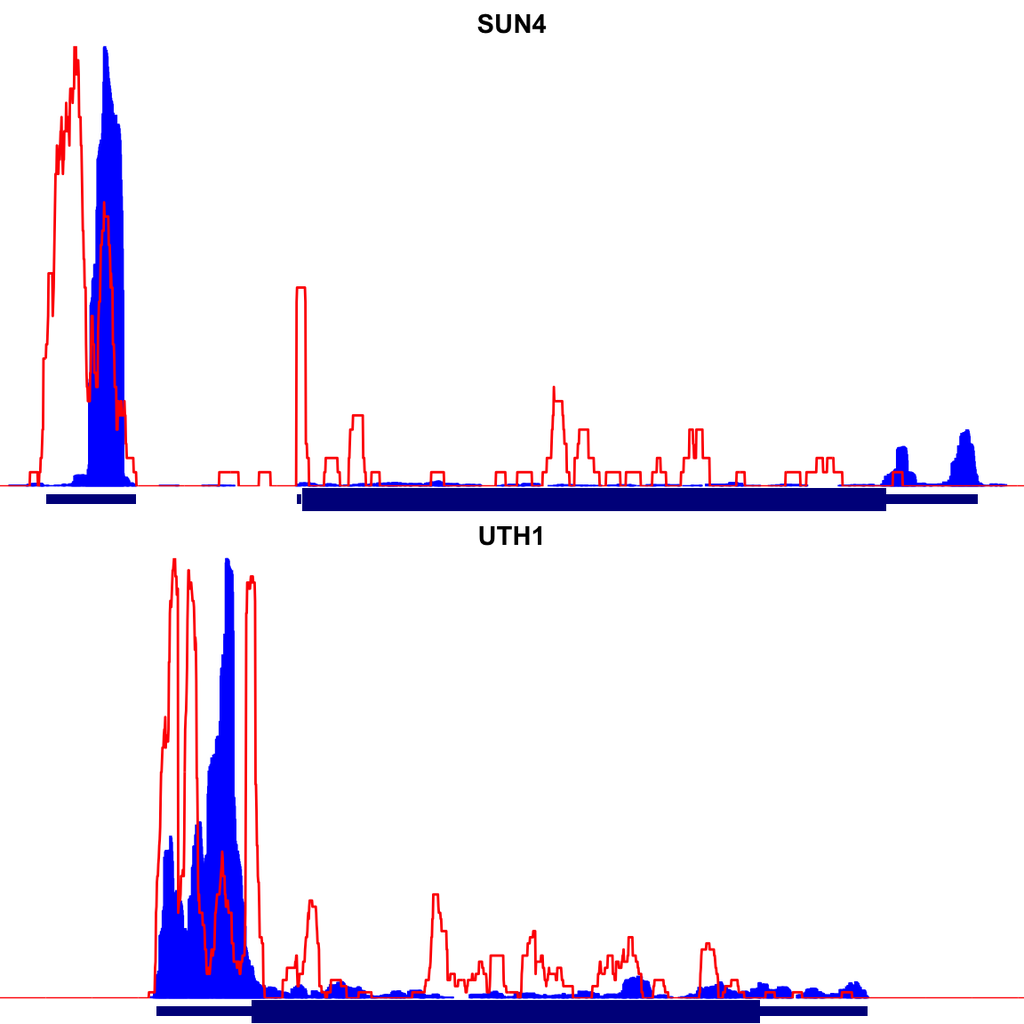

```r
# SUN4 starts 500962, ends 502975, length 2013
SUN4_A_bg <-
  plot_mRNAbg_pileup(bgbig=filter(bgall,Sample %in% c("A"),strand=="plus"),
           gff=gff_Sc,
           pileupSSU = pileups_WTSSU_over20, gene="YNL066W", ptitle="SUN4",pad=100)
# UTH1 starts 519320, ends 520858, length 1538
UTH1_A_bg <-
  plot_mRNAbg_pileup(bgbig=filter(bgall,Sample %in% c("A"),strand=="plus"),
           gff=gff_Sc,
           pileupSSU = pileups_WTSSU_over20, gene="YKR042W", ptitle="UTH1",pad=337)
plot_grid(SUN4_A_bg,UTH1_A_bg,
          ncol = 1)
```

```r
ggsave("figure/UTRs_SUN4_UTH1_withSSU.pdf", height = 3, width = 4)
```

This figure argues that ribosomal small subunit (SSU) pauses on the 5’UTR upstream of the Ssd1 peaks.